# ETC1010 Assignment 3

# MODEL OF LOG_PRICE, ROOMS<8, TYPE, DISTANCE AND BEDROOM2

```r
house_lm <- lm(log_Price ~ Rooms + Type + Distance + Bedroom2, data=house_2)
glance(house_lm)
```

```
##   r.squared adj.r.squared     sigma statistic p.value df   logLik
## 1 0.4901954     0.4900727 0.1601357  3995.758       0  6 8582.533
##         AIC       BIC deviance df.residual
## 1 -17151.07 -17095.47 532.8195       20778
```

# MODEL OF LOG_PRICE, ROOMS<8, TYPE, DISTANCE AND BEDROOM2<8

```r
house_lm <- lm(log_Price ~ Rooms + Type + Distance + Bedroom2, data=house_3)
glance(house_lm)
```

```
##   r.squared adj.r.squared    sigma statistic p.value df   logLik      AIC
## 1 0.4904416     0.4903189 0.160103  3998.541       0  6 8584.298 -17154.6
##      BIC deviance df.residual
## 1 -17099 532.4482       20772
```

The R squared and adjusted R squared are marginally higher for the model with bedroom2 restricted to less than 8 bedrooms, indicating that the model’s goodness of fit benefits from the restriction. This is reinforced by the marginally lower devariance in the model with bedroom2 less than 8 bedrooms.

The R squared and adjusted R squared are also marginally higher than the preivous model without the variable bedroom2, indicating that the addition of the bedroom2<8 variable to the model increases its goodness of fit and can explain a larger proportion of the variation in the log of price, where the model can explain about 49% of variation. This model also has a lower deviance which reinforces that it is a better model than the previous one.

# PLOT OF RELATIONSHIP BETWEEN LOG_PRICE AND BATHROOM

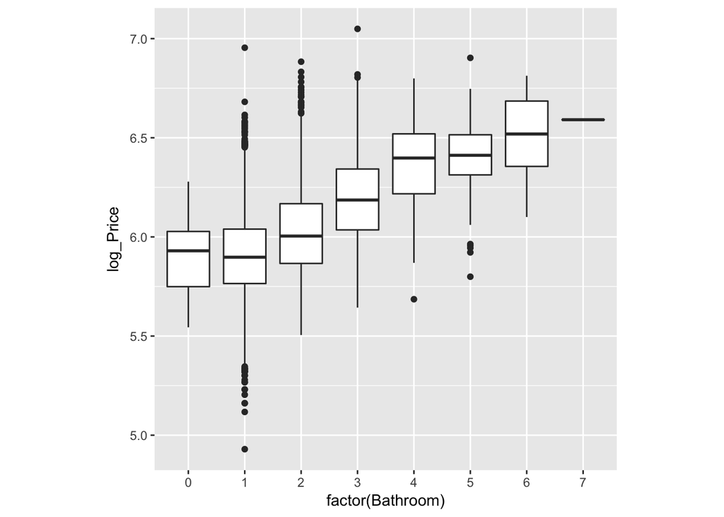

```r
ggplot(house_3, aes(x=factor(Bathroom), y=log_Price)) + geom_boxplot() +
  geom_smooth(method="lm", se=FALSE) + theme(aspect.ratio=1)
```

The plot shows that there are very few observations that have greater than 6 bathrooms, however they only extend to 7 which is insufficient to be filtered out as an extreme outlier. Hence, no filtering will be required for the variable bathroom.

The plot also shows that the IQR is relatively equal for all numbers of bathrooms except 5 bedroom which is slightly narrower. The plot also shows that as the number of bathrooms increases, so does the mean log of price. Again, this is plausible because housing with more bathrooms and therefore rooms are generally larger in size.

# MODEL OF LOG_PRICE, ROOMS<8, TYPE, DISTANCE, BEDROOM2<8 AND BATHROOM

```r
house_lm <- lm(log_Price ~ Rooms + Type + Distance + Bedroom2 + Bathroom, data=house_3)
glance(house_lm)
```

```
##   r.squared adj.r.squared     sigma statistic p.value df   logLik
## 1 0.5190007     0.5188617 0.1555555  3735.335       0  7 9183.522
##         AIC       BIC deviance df.residual
## 1 -18351.04 -18287.51 502.6062       20771
```

The R squared and adjusted R squared of this model are greater than the previous model by about 3% indicating that the addition of the Bathroom variable to the model increases its goodness of fit and can explain a larger proportion of the variation in the log of price, where the model can explain about 52% of variation. This model also has a lower deviance which reinforces that it is a better model than the previous one.

# MODEL OF LOG_PRICE, ROOMS * BEDROOM2, TYPE, DISTANCE AND BATHROOM

```r
house_lm <- lm(log_Price ~ Rooms*Bedroom2 + Type + Distance + Bathroom, data=house_3)
glance(house_lm)
```

```
##   r.squared adj.r.squared     sigma statistic p.value df   logLik
## 1 0.5271235     0.5269641 0.1542401  3307.524       0  8 9360.463
##         AIC       BIC deviance df.residual
## 1 -18702.93 -18631.45 494.1186       20770
```

It is plausible that there would be an interaction term between rooms and bedroom2 because as the number of bedrooms increases, so do the number of rooms. The addition of this interaction term is also justified because the R squared and adjusted R squared of this model are marginally greater than the previous model, indicating that the addition of the interaction term between rooms and bedroom2 to the model increases its goodness of fit and can explain a larger proportion of the variation in the log of price, where the model can explaina bout 52% of variation. This model also has a lower deviance which reinforces that it is a better model than the previous one.

# MODEL OF LOG_PRICE, ROOMS * BEDROOM2 * BATHROOM, TYPE AND DISTANCE

```r
house_lm <- lm(log_Price ~ Rooms*Bedroom2*Bathroom + Type + Distance, data=house_3)
glance(house_lm)
```

```
##   r.squared adj.r.squared     sigma statistic p.value df   logLik
## 1   0.52932     0.5290933 0.1538926  2335.427       0 11 9408.831
##         AIC       BIC deviance df.residual
## 1 -18793.66 -18698.36 491.8234       20767
```

It is plausible that there would be an interaction term between rooms and bedroom2 and bathroom because as the number of bathrooms increases, so do the number of rooms and number of bedrooms that can be accommodated for. The addition of this interaction term is also justified because the R squared and adjusted R squared of this model are marginally greater than the previous model, indicating that the addition of the interaction term between rooms, bedroom2 and bathroom to the model increases its goodness of fit and can explain a larger proportion of the variation in the log of price, where the model can explaina bout 53% of variation. This model also has a lower deviance which reinforces that it is a better model than the previous one.

# MODEL OF LOG_PRICE, ROOMS * BEDROOM2 * BATHROOM * TYPE AND DISTANCE

```r
house_lm <- lm(log_Price ~ Rooms*Bedroom2*Bathroom*Type + Distance, data=house_3)
glance(house_lm)
```

```
##   r.squared adj.r.squared     sigma statistic p.value df   logLik
## 1 0.5367361     0.5362003 0.1527269  1001.848       0 25 9573.826
##         AIC       BIC deviance df.residual
## 1 -19095.65 -18889.17 484.0741       20753
```

It is plausible that there would be an interaction term between rooms, bedroom2, bathroom and type because the number of bedrooms and bathrooms will determine the number of total rooms, which will in turn determine the total size of the housing, which determines the possible type of housing. E.g. Units are generally small in square footage, so it would be expected that they would have fewer rooms than a house. The addition of this interaction term is also justified because the R squared and adjusted R squared of this model are marginally greater than the previous model, indicating that the addition of the interaction term between rooms, bedroom2, bathroom and type to the model increases its goodness of fit and can explain a larger proportion of the variation in the log of price, where the model can explaina bout 54% of variation. This model also has a lower deviance which reinforces that it is a better model than the previous one.

# MODEL OF LOG_PRICE, ROOMS * BEDROOM2 * BATHROOM * TYPE * DISTANCE

```r
house_lm <- lm(log_Price ~ Rooms*Bedroom2*Bathroom*Type*Distance, data=house_3)
glance(house_lm)
```

```
##   r.squared adj.r.squared     sigma statistic p.value df   logLik
## 1 0.5481668     0.5471424 0.1509146  535.1013       0 48 9833.382
##         AIC       BIC deviance df.residual
## 1 -19568.76 -19179.62   472.13       20730
```

It is plausible that there would be an interaction term between rooms, bedroom2, bathroom, type and distance because the number of bedrooms and bathrooms will determine the number of total rooms, which will in turn determine the total size of the housing, which determines the possible type of housing which also determines the distance of the housing from the CBD. E.g. Units are generally small in square footage, so it would be expected that they would have fewer rooms than a house, and since units inhabit less area, they would use less of the competitive CBD land than a house. The addition of this interaction term is also justified because the R squared and adjusted R squared of this model are marginally greater than the previous model, indicating that the addition of the interaction term between rooms, bedroom2, bathroom, type and distance to the model increases its goodness of fit and can explain a larger proportion of the variation in the log of price, where the model can explaina bout 55% of variation. This model also has a lower deviance which reinforces that it is a better model than the previous one.

# WHY THIS IS THE BEST MODEL

Given the variables Rooms, Bedroom2, Bathroom, Type and Distance, lm(log_Price ~ Rooms*Bedroom2*Bathroom*Type*Distance, data=house_3) is the best model to predict the log of price because they all have a plausible effect on the log of price of housing. Additionally, this model has the best goodness of fit measures amongst the models that have been prevously tested as the R squared and adjusted R squared is the highest and the deviance is the lowest.